# financial sentiment

```python
import numpy as np
import pandas as pd
import matplotlib.pyplot as plt
import seaborn as sns
from sklearn.preprocessing import LabelEncoder
from imblearn.over_sampling import SMOTE
from sklearn.feature_extraction.text import CountVectorizer
from sklearn.feature_extraction.text import TfidfVectorizer
from sklearn.linear_model import LogisticRegression
from sklearn.neighbors import KNeighborsClassifier
from sklearn.svm import SVC
from sklearn.tree import DecisionTreeClassifier
from sklearn.naive_bayes import MultinomialNB
from sklearn.discriminant_analysis import LinearDiscriminantAnalysis
from xgboost import XGBClassifier
from sklearn.model_selection import train_test_split
from sklearn.metrics import classification_report
from sklearn.metrics import accuracy_score, confusion_matrix
from sklearn.metrics import precision_score, recall_score
from sklearn.model_selection import StratifiedKFold
from sklearn.model_selection import cross_val_score
from imblearn.over_sampling import SMOTE

import re
import nltk
from nltk.tokenize import word_tokenize
from nltk.corpus import stopwords
from nltk.stem import WordNetLemmatizer
import tensorflow as tf
from tensorflow.keras.models import Sequential
from tensorflow.keras.layers import Embedding, LSTM, Dropout, Dense
from tensorflow.keras.preprocessing.text import Tokenizer
from tensorflow.keras.preprocessing.sequence import pad_sequences
from tensorflow.keras.callbacks import EarlyStopping
from tensorflow.keras.utils import to_categorical
from tensorflow.keras.layers import SpatialDropout1D, Activation

nltk.download('stopwords')
nltk.download('punkt')
nltk.download('wordnet')
nltk.download('omw-1.4')
nltk.download('punkt_tab')
```

```
True
```

```python
from google.colab import files
uploaded = files.upload()
```

Upload widget is only available when the cell has been executed in the current browser session. Please rerun this cell to enable.

```
Saving financial sentiment analysis.csv to financial sentiment analysis (1).csv
```

```python
df = pd.read_csv('financial sentiment analysis.csv')
```

```python
df.head()
```

|  | Sentence | Sentiment |
| --- | --- | --- |
| 0 | The GeoSolutions technology will leverage Bene... | positive |
| 1 | $ESI on lows, down $1.50 to $2.50 BK a real po... | negative |
| 2 | For the last quarter of 2010 , Componenta 's n... | positive |
| 3 | According to the Finnish-Russian Chamber of Co... | neutral |
| 4 | The Swedish buyout firm has sold its remaining... | neutral |

```python
#missing values
df.isnull().sum()
```

|  | 0 |
| --- | --- |
| Sentence | 0 |
| Sentiment | 0 |

**dtype:** int64

```python
df.duplicated().sum()
```

```
np.int64(6)
```

```python
#remove the duplicates
df=df.drop_duplicates()
```

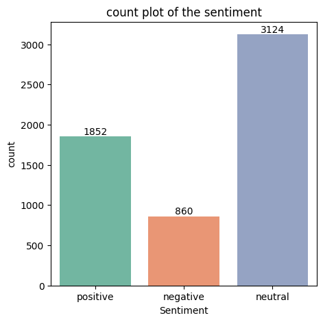

```python
#count plot for sentiment column

plt.figure(figsize=(5,5))
sns.countplot(x="Sentiment",data=df,palette="Set2")
plt.title("count plot of the sentiment")

# Adding data labels on top of the bars
for bar in plt.gca().patches:
    height = bar.get_height()
    x = bar.get_x() + bar.get_width() / 2
    plt.text(x, height, str(int(height)), ha='center', va='bottom')
```

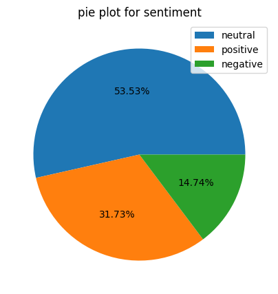

```python
#pie plot for sentiment column

labels=["neutral","positive","negative"]
plt.figure(figsize=(5,5))
plt.pie(x=df["Sentiment"].value_counts(),autopct="%0.2f%%")
plt.title("pie plot for sentiment")
plt.legend(labels)
```

```python
#applying label encoding to sentiment column

le=LabelEncoder()
df["Sentiment"]=le.fit_transform(df["Sentiment"])

df["Sentiment"].unique()
```

```
array([2, 0, 1])
```

```python
#cleaning

stop=set(stopwords.words("english"))
lemmatizer=WordNetLemmatizer()


def clean_text(text):
    text = re.sub(r"won\'t", "will not", text)
    text = re.sub(r"can\'t", "can not", text)
    text = re.sub(r"n\'t", " not", text)
    text = re.sub(r"\'re", " are", text)
    text = re.sub(r"\'s", " is", text)
    text = re.sub(r"\'d", " would",text)
    text = re.sub(r"\'ll", " will", text)
    text = re.sub(r"\'t", " not", text)
    text = re.sub(r"\'ve", " have", text)
    text = re.sub(r"\'m", " am", text)
    text = re.sub('[^a-zA-Z]',' ',text)
    text = re.sub(r"[^\w\s]"," ",text.lower())
    text = re.sub(r"\s+"," ",text)
    tokens=word_tokenize(text)
    output=[lemmatizer.lemmatize(words) for words in tokens if words.isalpha() and words not in stop]
    return " ".join(output)
```

```python
df["clean text"]=df["Sentence"].apply(clean_text)
```

```python
#Creating the Bag of Words model (BoW)
#countvectorizer

vectorizer=CountVectorizer()
x=vectorizer.fit_transform(df["clean text"])
y=df["Sentiment"]
```

```python
#balnce the sentiment column

smote=SMOTE()

x,y=smote.fit_resample(x,y)

print(y.value_counts())
```

```
Sentiment
2    3124
0    3124
1    3124
Name: count, dtype: int64
```

```python
#train_test split
x_train,x_test,y_train,y_test=train_test_split(x,y,test_size=0.2,random_state=42)
```

```python
models={"LogisticRegression":LogisticRegression(),
        "Naive Bayes":MultinomialNB(),
        "SVC":SVC(),
        "KNN":KNeighborsClassifier(),
        "xgboost":XGBClassifier()}


for name, model in models.items():
    if name=="Naive Bayes":
        model.fit(x_train.toarray(),y_train)
        y_pred_train=model.predict(x_train.toarray())
        y_pred=model.predict(x_test.toarray())

    else:
        model.fit(x_train,y_train)
        y_pred_train=model.predict(x_train)
        y_pred=model.predict(x_test)

    print(f"{name}")
    print("train accuracy: ",accuracy_score(y_train,y_pred_train))
    print("test accuracy: ",accuracy_score(y_test,y_pred))
    print(classification_report(y_test,y_pred))
    print(confusion_matrix(y_test,y_pred))
    print("*"*50)
```

```
LogisticRegression
train accuracy:  0.8486061091103108
test accuracy:  0.6725333333333333
              precision    recall  f1-score   support

           0       0.60      0.82      0.69       623
           1       0.75      0.65      0.69       642
           2       0.72      0.55      0.62       610

    accuracy                           0.67      1875
   macro avg       0.69      0.67      0.67      1875
weighted avg       0.69      0.67      0.67      1875

[[511  71  41]
 [136 417  89]
 [206  71 333]]
Naive Bayes
train accuracy:  0.720688275310124
test accuracy:  0.6256
              precision    recall  f1-score   support

           0       0.57      0.51      0.54       623
           1       0.74      0.74      0.74       642
           2       0.56      0.63      0.59       610

    accuracy                           0.63      1875
   macro avg       0.62      0.62      0.62      1875
weighted avg       0.63      0.63      0.62      1875

[[315  67 241]
 [105 475  62]
 [130  97 383]]
SVC
train accuracy:  0.8352674403094571
test accuracy:  0.6704
              precision    recall  f1-score   support

           0       0.60      0.81      0.69       623
           1       0.70      0.77      0.73       642
           2       0.77      0.43      0.55       610
```

[output cut: 25 more lines]

```
train accuracy:  0.8659463785514205
test accuracy:  0.7946666666666666
              precision    recall  f1-score   support

           0       0.84      0.78      0.81       623
           1       0.71      0.84      0.77       642
           2       0.87      0.76      0.81       610

    accuracy                           0.79      1875
   macro avg       0.81      0.79      0.80      1875
weighted avg       0.81      0.79      0.80      1875

[[487 105  31]
 [ 63 542  37]
 [ 28 121 461]]
```

```python
#TF_IDF vectorizer

tfvectorizer=TfidfVectorizer()
x=tfvectorizer.fit_transform(df["clean text"])
y=df["Sentiment"]
```

```python
#balnce the sentiment column

smote=SMOTE()

x,y=smote.fit_resample(x,y)

print(y.value_counts())
```

```
Sentiment
2    3124
0    3124
1    3124
Name: count, dtype: int64
```

```python
for name, model in models.items():
    if name=="Naive Bayes":
        model.fit(x_train.toarray(),y_train)
        y_pred_train=model.predict(x_train.toarray())
        y_pred=model.predict(x_test.toarray())

    else:
        model.fit(x_train,y_train)
        y_pred_train=model.predict(x_train)
        y_pred=model.predict(x_test)

    print(f"{name}")
    print("train accuracy: ",accuracy_score(y_train,y_pred_train))
    print("test accuracy: ",accuracy_score(y_test,y_pred))
    print(classification_report(y_test,y_pred))
    print(confusion_matrix(y_test,y_pred))
    print("*"*50)
```

```
LogisticRegression
train accuracy:  0.8486061091103108
test accuracy:  0.6725333333333333
              precision    recall  f1-score   support

           0       0.60      0.82      0.69       623
           1       0.75      0.65      0.69       642
           2       0.72      0.55      0.62       610

    accuracy                           0.67      1875
   macro avg       0.69      0.67      0.67      1875
weighted avg       0.69      0.67      0.67      1875

[[511  71  41]
 [136 417  89]
 [206  71 333]]
Naive Bayes
train accuracy:  0.720688275310124
test accuracy:  0.6256
              precision    recall  f1-score   support

           0       0.57      0.51      0.54       623
           1       0.74      0.74      0.74       642
           2       0.56      0.63      0.59       610

    accuracy                           0.63      1875
   macro avg       0.62      0.62      0.62      1875
weighted avg       0.63      0.63      0.62      1875

[[315  67 241]
 [105 475  62]
 [130  97 383]]
SVC
train accuracy:  0.8352674403094571
test accuracy:  0.6704
              precision    recall  f1-score   support

           0       0.60      0.81      0.69       623
           1       0.70      0.77      0.73       642
           2       0.77      0.43      0.55       610
```

[output cut: 25 more lines]

```
train accuracy:  0.8659463785514205
test accuracy:  0.7946666666666666
              precision    recall  f1-score   support

           0       0.84      0.78      0.81       623
           1       0.71      0.84      0.77       642
           2       0.87      0.76      0.81       610

    accuracy                           0.79      1875
   macro avg       0.81      0.79      0.80      1875
weighted avg       0.81      0.79      0.80      1875

[[487 105  31]
 [ 63 542  37]
 [ 28 121 461]]
```

# *cross validation*

```
----- Model: LogisticRegression -----
Fold 0 - Precision: 0.6866, Recall: 0.6866
Fold 1 - Precision: 0.6650, Recall: 0.6650
Fold 2 - Precision: 0.6675, Recall: 0.6675
Fold 3 - Precision: 0.6632, Recall: 0.6632
Fold 4 - Precision: 0.6504, Recall: 0.6504

Average Precision for LogisticRegression: 0.6665
Average Recall for LogisticRegression: 0.6665

Classification Report (last fold):
              precision    recall  f1-score   support

           2       0.71      0.65      0.68       371
           0       0.30      0.24      0.27       172
           1       0.69      0.76      0.73       624

    accuracy                           0.65      1167
   macro avg       0.57      0.55      0.56      1167
weighted avg       0.64      0.65      0.64      1167


----- Model: Naive Bayes -----
Fold 0 - Precision: 0.6849, Recall: 0.6849
Fold 1 - Precision: 0.6667, Recall: 0.6667
Fold 2 - Precision: 0.6975, Recall: 0.6975
Fold 3 - Precision: 0.6915, Recall: 0.6915
Fold 4 - Precision: 0.6607, Recall: 0.6607

Average Precision for Naive Bayes: 0.6803
Average Recall for Naive Bayes: 0.6803

Classification Report (last fold):
              precision    recall  f1-score   support

           2       0.69      0.61      0.65       371
           0       0.35      0.31      0.33       172
           1       0.72      0.79      0.75       624

    accuracy                           0.66      1167
```

[output cut: 34 more lines]

```
Average Recall for KNN: 0.5684

Classification Report (last fold):
              precision    recall  f1-score   support

           2       0.69      0.23      0.34       371
           0       0.24      0.12      0.16       172
           1       0.58      0.89      0.70       624

    accuracy                           0.57      1167
   macro avg       0.50      0.41      0.40      1167
weighted avg       0.56      0.57      0.51      1167


----- Model: XGBoost -----
```

```
Fold 0 - Precision: 0.6841, Recall: 0.6841
```

```
Fold 1 - Precision: 0.6632, Recall: 0.6632
```

```
Fold 2 - Precision: 0.6769, Recall: 0.6769
```

```
Fold 3 - Precision: 0.6727, Recall: 0.6727
```

```
Fold 4 - Precision: 0.6812, Recall: 0.6812

Average Precision for XGBoost: 0.6756
Average Recall for XGBoost: 0.6756

Classification Report (last fold):
              precision    recall  f1-score   support

           2       0.78      0.59      0.67       371
           0       0.39      0.22      0.28       172
           1       0.68      0.86      0.76       624

    accuracy                           0.68      1167
   macro avg       0.62      0.56      0.57      1167
weighted avg       0.67      0.68      0.66      1167
```

[figure not shown]

```python
# cross validation and Count vectorizer

# Shuffle and prepare data
df = df.sample(frac=1).reset_index(drop=True)
df['fold'] = -1

# Set input (text) and target (label)
x = df["clean text"]
y = df['Sentiment']

# 5-Fold setup
n = 5
kf = StratifiedKFold(n_splits=n)

# Assign fold numbers
for k, (train_idx, test_idx) in enumerate(kf.split(x, y)):
    df.loc[test_idx, 'fold'] = k

# Define models
models = {
    "LogisticRegression": LogisticRegression(),
    "Naive Bayes": MultinomialNB(),
    "SVC": SVC(),
    "KNN": KNeighborsClassifier(),
    "XGBoost": XGBClassifier(use_label_encoder=False, eval_metric='mlogloss')
}

# Create dictionary to save results
results = {}

# Try each model
for model_name, model_instance in models.items():
    print(f"\n----- Model: {model_name} -----")

    precision_scores = []
    recall_scores = []

    for k in range(n):
        train = df[df.fold != k].reset_index(drop=True)
        test = df[df.fold == k].reset_index(drop=True)

        # Create a fresh TF-IDF vectorizer for every fold
        vectorizer = CountVectorizer()

        # Fit vectorizer only on training text
        vectorizer.fit(train["clean text"])

        # Transform texts into vectors
        x_train = vectorizer.transform(train["clean text"])
        y_train = train["Sentiment"]

        x_test = vectorizer.transform(test["clean text"])
        y_test = test["Sentiment"]

        # Create a new model instance for each fold
        model = model_instance.__class__(**model_instance.get_params())
        model.fit(x_train, y_train)

        # Predict
        preds = model.predict(x_test)

        # Metrics
        precision = precision_score(y_test, preds, average='micro')
        recall = recall_score(y_test, preds, average='micro')

        precision_scores.append(precision)
        recall_scores.append(recall)

        print(f"Fold {k} - Precision: {precision:.4f}, Recall: {recall:.4f}")

    # After all folds, show average scores
    avg_precision = sum(precision_scores) / n
    avg_recall = sum(recall_scores) / n

    print(f"\nAverage Precision for {model_name}: {avg_precision:.4f}")
    print(f"Average Recall for {model_name}: {avg_recall:.4f}")

    # Save average precision for plotting
    results[model_name] = avg_precision

    # Show final classification report (for last fold)
    print("\nClassification Report (last fold):")
    print(classification_report(y_test, preds, labels=[2, 0, 1]))
    print("*" * 60)

# =====================
# Now Plotting Results
# =====================

model_names = list(results.keys())
average_precisions = list(results.values())

plt.figure(figsize=(10,6))
plt.barh(model_names, average_precisions)
plt.xlabel("Mean CV Precision Score")
plt.title("Model Comparison (TF-IDF + StratifiedKFold)")
for index, value in enumerate(average_precisions):
    plt.text(value + 0.01, index, f"{value:.2f}")
plt.xlim(0, 1)
plt.grid(True)
plt.show()
```

```
----- Model: LogisticRegression -----
Fold 0 - Precision: 0.6961, Recall: 0.6961
Fold 1 - Precision: 0.6898, Recall: 0.6898
Fold 2 - Precision: 0.6907, Recall: 0.6907
Fold 3 - Precision: 0.6992, Recall: 0.6992
Fold 4 - Precision: 0.6984, Recall: 0.6984

Average Precision for LogisticRegression: 0.6948
Average Recall for LogisticRegression: 0.6948

Classification Report (last fold):
              precision    recall  f1-score   support

           2       0.76      0.61      0.68       370
           0       0.47      0.16      0.24       172
           1       0.69      0.90      0.78       625

    accuracy                           0.70      1167
   macro avg       0.64      0.56      0.57      1167
weighted avg       0.68      0.70      0.67      1167


----- Model: Naive Bayes -----
Fold 0 - Precision: 0.6592, Recall: 0.6592
Fold 1 - Precision: 0.6684, Recall: 0.6684
Fold 2 - Precision: 0.6632, Recall: 0.6632
Fold 3 - Precision: 0.6667, Recall: 0.6667
Fold 4 - Precision: 0.6650, Recall: 0.6650

Average Precision for Naive Bayes: 0.6645
Average Recall for Naive Bayes: 0.6645

Classification Report (last fold):
              precision    recall  f1-score   support

           2       0.74      0.44      0.55       370
           0       1.00      0.03      0.07       172
           1       0.65      0.97      0.78       625

    accuracy                           0.66      1167
```

[output cut: 34 more lines]

```
Average Recall for KNN: 0.6151

Classification Report (last fold):
              precision    recall  f1-score   support

           2       0.74      0.42      0.53       370
           0       0.36      0.29      0.32       172
           1       0.66      0.86      0.74       625

    accuracy                           0.63      1167
   macro avg       0.58      0.52      0.53      1167
weighted avg       0.64      0.63      0.61      1167


----- Model: XGBoost -----
```

```
Fold 0 - Precision: 0.6558, Recall: 0.6558
```

```
Fold 1 - Precision: 0.6641, Recall: 0.6641
```

```
Fold 2 - Precision: 0.6624, Recall: 0.6624
```

```
Fold 3 - Precision: 0.6701, Recall: 0.6701
```

```
Fold 4 - Precision: 0.6692, Recall: 0.6692

Average Precision for XGBoost: 0.6643
Average Recall for XGBoost: 0.6643

Classification Report (last fold):
              precision    recall  f1-score   support

           2       0.83      0.57      0.68       370
           0       0.33      0.22      0.26       172
           1       0.67      0.85      0.75       625

    accuracy                           0.67      1167
   macro avg       0.61      0.55      0.56      1167
weighted avg       0.67      0.67      0.65      1167
```

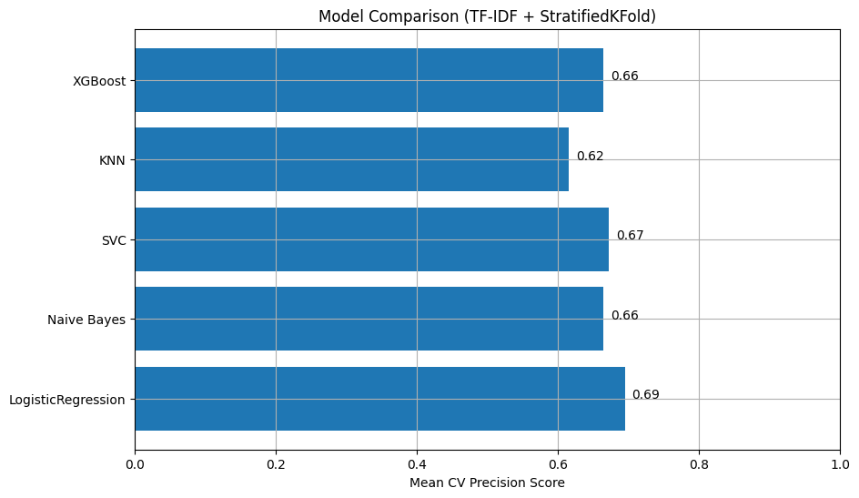

```python
#cross validation for selected models in TF_IDF vectorizer

# Shuffle and prepare data
df = df.sample(frac=1).reset_index(drop=True)
df['fold'] = -1

# Set input (text) and target (label)
x = df["clean text"]
y = df['Sentiment']

# 5-Fold setup
n = 5
kf = StratifiedKFold(n_splits=n)

# Assign fold numbers
for k, (train_idx, test_idx) in enumerate(kf.split(x, y)):
    df.loc[test_idx, 'fold'] = k

# Define models
models = {
    "LogisticRegression": LogisticRegression(),
    "Naive Bayes": MultinomialNB(),
    "SVC": SVC(),
    "KNN": KNeighborsClassifier(),
    "XGBoost": XGBClassifier(use_label_encoder=False, eval_metric='mlogloss')
}

# Create dictionary to save results
results = {}

# Try each model
for model_name, model_instance in models.items():
    print(f"\n----- Model: {model_name} -----")

    precision_scores = []
    recall_scores = []

    for k in range(n):
        train = df[df.fold != k].reset_index(drop=True)
        test = df[df.fold == k].reset_index(drop=True)

        # Create a fresh TF-IDF vectorizer for every fold
        vectorizer = TfidfVectorizer()

        # Fit vectorizer only on training text
        vectorizer.fit(train["clean text"])

        # Transform texts into vectors
        x_train = vectorizer.transform(train["clean text"])
        y_train = train["Sentiment"]

        x_test = vectorizer.transform(test["clean text"])
        y_test = test["Sentiment"]

        # Create a new model instance for each fold
        model = model_instance.__class__(**model_instance.get_params())
        model.fit(x_train, y_train)

        # Predict
        preds = model.predict(x_test)

        # Metrics
        precision = precision_score(y_test, preds, average='micro')
        recall = recall_score(y_test, preds, average='micro')

        precision_scores.append(precision)
        recall_scores.append(recall)

        print(f"Fold {k} - Precision: {precision:.4f}, Recall: {recall:.4f}")

    # After all folds, show average scores
    avg_precision = sum(precision_scores) / n
    avg_recall = sum(recall_scores) / n

    print(f"\nAverage Precision for {model_name}: {avg_precision:.4f}")
    print(f"Average Recall for {model_name}: {avg_recall:.4f}")

    # Save average precision for plotting
    results[model_name] = avg_precision

    # Show final classification report (for last fold)
    print("\nClassification Report (last fold):")
    print(classification_report(y_test, preds, labels=[2, 0, 1]))
    print("*" * 60)

# =====================
# Now Plotting Results
# =====================

model_names = list(results.keys())
average_precisions = list(results.values())

plt.figure(figsize=(10,6))
plt.barh(model_names, average_precisions)
plt.xlabel("Mean CV Precision Score")
plt.title("Model Comparison (TF-IDF + StratifiedKFold)")
for index, value in enumerate(average_precisions):
    plt.text(value + 0.01, index, f"{value:.2f}")
plt.xlim(0, 1)
plt.grid(True)
plt.show()
```

# **Lexicon-Based (VADER, TextBlob)**

```python
!pip install vaderSentiment
```

```python
from vaderSentiment.vaderSentiment import SentimentIntensityAnalyzer
from textblob import TextBlob

analyser=SentimentIntensityAnalyzer()

def get_sentiment(text):
    return analyser.polarity_scores(str(text))

df["clean text"].apply(get_sentiment)[1]
```

```
{'neg': 0.0, 'neu': 0.647, 'pos': 0.353, 'compound': 0.5994}
```

```python
#subjectivity and polarity from textblob

def get_subjectivity(text):
    return TextBlob(text).sentiment.subjectivity

def get_polarity(text):
    return TextBlob(text).sentiment.polarity
```

```python
#creating compound,neg, pos and neu
compound=[]
neg=[]
pos=[]
neu=[]

for i in range(0, len(df["clean text"])):
    SIA=get_sentiment(df["clean text"].iloc[i])
    compound.append(SIA["compound"])
    neg.append(SIA["neg"])
    pos.append(SIA["pos"])
    neu.append(SIA["neu"])

df["compound"]=compound
df["neg"]=neg
df["pos"]=pos
df["neu"]=neu
```

```python
df["subjectivity"]=df["clean text"].apply(get_subjectivity)
df["polarity"]=df["clean text"].apply(get_polarity)
```

```python
#linear Discrminant analysis

x=df[["compound","neg","pos","neu","subjectivity","polarity"]]
y=df["Sentiment"]

smote=SMOTE()
x,y=smote.fit_resample(x,y)

x_train,x_test,y_train,y_test=train_test_split(x,y,test_size=0.2,random_state=42)

lda=LinearDiscriminantAnalysis()
model=lda.fit(x_train,y_train)
y_pred=model.predict(x_test)
y_pred_train=model.predict(x_train)
print("train accuracy: ",accuracy_score(y_train,y_pred_train))
print("test_accuracy: ",accuracy_score(y_test,y_pred))
print(classification_report(y_test,y_pred))
```

```
train accuracy:  0.5064692543684141
test_accuracy:  0.5136
              precision    recall  f1-score   support

           0       0.64      0.44      0.52       619
           1       0.45      0.55      0.49       608
           2       0.50      0.55      0.53       648

    accuracy                           0.51      1875
   macro avg       0.53      0.51      0.51      1875
weighted avg       0.53      0.51      0.51      1875
```

```python
models={"LogisticRegression":LogisticRegression(),
        "LDA":LinearDiscriminantAnalysis(),
        "SVC":SVC(),
        "KNN":KNeighborsClassifier(),
        "xgboost":XGBClassifier()}


for name, model in models.items():
    if name=="LDA":
        model.fit(x_train,y_train)
        y_pred_train=model.predict(x_train)
        y_pred=model.predict(x_test)

    else:
        model.fit(x_train,y_train)
        y_pred_train=model.predict(x_train)
        y_pred=model.predict(x_test)

    print(f"{name}")
    print("train accuracy: ",accuracy_score(y_train,y_pred_train))
    print("test accuracy: ",accuracy_score(y_test,y_pred))
    print(classification_report(y_test,y_pred))
    print(confusion_matrix(y_test,y_pred))
    print("*"*50)
```

```
LogisticRegression
train accuracy:  0.5056689342403629
test accuracy:  0.5136
              precision    recall  f1-score   support

           0       0.63      0.44      0.52       619
           1       0.45      0.53      0.48       608
           2       0.51      0.57      0.54       648

    accuracy                           0.51      1875
   macro avg       0.53      0.51      0.51      1875
weighted avg       0.53      0.51      0.51      1875

[[273 193 153]
 [ 82 320 206]
 [ 76 202 370]]
LDA
train accuracy:  0.5064692543684141
test accuracy:  0.5136
              precision    recall  f1-score   support

           0       0.64      0.44      0.52       619
           1       0.45      0.55      0.49       608
           2       0.50      0.55      0.53       648

    accuracy                           0.51      1875
   macro avg       0.53      0.51      0.51      1875
weighted avg       0.53      0.51      0.51      1875

[[272 189 158]
 [ 82 332 194]
 [ 74 215 359]]
SVC
train accuracy:  0.5127384287048152
test accuracy:  0.5253333333333333
              precision    recall  f1-score   support

           0       0.63      0.49      0.55       619
           1       0.46      0.50      0.48       608
           2       0.51      0.58      0.54       648
```

[output cut: 25 more lines]

```
train accuracy:  0.7556355875683607
test accuracy:  0.6234666666666666
              precision    recall  f1-score   support

           0       0.68      0.68      0.68       619
           1       0.52      0.62      0.57       608
           2       0.70      0.57      0.63       648

    accuracy                           0.62      1875
   macro avg       0.63      0.62      0.63      1875
weighted avg       0.64      0.62      0.63      1875

[[421 145  53]
 [124 380 104]
 [ 72 208 368]]
```

"We took numbers from VADER and TextBlob that describe the feeling of each text (like how positive or negative it is). Then, we used these numbers to train different machine learning models to predict the sentiment.

The models were about 50–60% correct, which means these simple sentiment scores give some useful information, but not enough to make very strong predictions.

To do better in the future, we would need more powerful tools that understand financial language better, like a model called FinBERT, or use deeper machine learning methods that learn from full sentences."

In this project, I performed sentiment classification on financial news headlines using a complete machine learning pipeline. I applied text preprocessing, feature engineering (TF-IDF, CountVectorizer, VADER, TextBlob), handled class imbalance with SMOTE, and trained multiple models including Logistic Regression, Naive Bayes, SVM, KNN, XGBoost, and LDA. I compared the performance of different vectorization techniques and sentiment-based features through cross-validation and visualization.